# Bias correction TRMM and VALUE observations time series in the Iberian Peninsula during 1998-2010

Óscar Mirones Alonso

Abstract

In this notebook, several standard bias correction methods are made. Four main methods are computed with the biasCorrection function (scale, eqm, pqm and gpqm). Then, the calibrated time series is compared with the observational time series. Also, the comparision between the TRMM time series and the observational time series is made. The goal is is to find out if the calibration is an improvement of the precipitation time series with respect to the TRMM series.

```r
library(loadeR)
library(transformeR)
library(downscaleR)
library(visualizeR)
library(ncdf4)
library(Metrics)
```

Load the VALUE package to obtain observational data

```r
library(VALUE)
value.dataset <- file.path(find.package("VALUE"), "example_datasets", "VALUE_ECA_86_v2.zip")

obs <- loadStationData(dataset = value.dataset, var = "precip",
                              lonLim = c(-10,4.5),
                              latLim = c(34.7,44))
```

```
[2020-12-22 11:31:33] Loading data ...
Warning in .Internal(gc(verbose, reset, full)) :
  closing unused connection 4 (C:/Users/usuario/Documents/R/win-library/4.0/VALUE/example_datasets/VALUE_ECA_86_v2.zip:VALUE_ECA_86_v3/precip.txt)
[2020-12-22 11:31:34] Retrieving metadata ...
the condition has length > 1 and only the first element will be used[2020-12-22 11:31:35] Done.
```

```r
str(obs)
```

```
List of 5
 $ Variable:List of 2
  ..$ varName: chr "precip"
  ..$ level  : NULL
  ..- attr(*, "units")= chr "mm"
 $ Data    : num [1:18262, 1:11] 0.1 9.4 3.1 0.8 0.1 0.1 0.8 0.4 1.4 3.8 ...
  ..- attr(*, "dimensions")= chr [1:2] "time" "loc"
 $ xyCoords:'data.frame':   11 obs. of  2 variables:
  ..$ x: num [1:11] -6.73 -9.15 -6.83 -4.49 -4.01 ...
  ..$ y: num [1:11] 41.8 38.7 38.9 36.7 40.8 ...
  ..- attr(*, "projection")= chr "+proj=longlat +init=epsg:4326 +datum=WGS84 +no_defs +ellps=WGS84 +towgs84=0,0,0"
  ..- attr(*, "resX")= num 0
  ..- attr(*, "resY")= num 0
 $ Dates   :List of 2
  ..$ start: chr [1:18262] "1961-01-01 00:00:00" "1961-01-02 00:00:00" "1961-01-03 00:00:00" "1961-01-04 00:00:00" ...
  ..$ end  : chr [1:18262] "1961-01-02 00:00:00" "1961-01-03 00:00:00" "1961-01-04 00:00:00" "1961-01-05 00:00:00" ...
 $ Metadata:List of 5
  ..$ station_id    : chr [1:11] "000212" "000214" "000229" "000231" ...
  ..$ name          : chr [1:11] "BRAGANCA" "LISBOA-GEOFISICA" "BADAJOZ-TALAVERA LA REAL" "MALAGA" ...
  ..$ altitude      : int [1:11] 690 77 185 7 1894 251 44 151 370 8 ...
  ..$ source        : chr [1:11] "ECA&D" "ECA&D" "ECA&D" "ECA&D" ...
  ..$ PRUDENCEregion: chr [1:11] "IP" "IP" "IP" "IP" ...
 - attr(*, "dataset")= chr "C:/Users/usuario/Documents/R/win-library/4.0/VALUE/example_datasets/VALUE_ECA_86_v2.zip"
 - attr(*, "R_package_desc")= chr "loadeR-v1.7.0"
 - attr(*, "R_package_URL")= chr "https://github.com/SantanderMetGroup/loadeR"
 - attr(*, "R_package_ref")= chr "https://doi.org/10.1016/j.envsoft.2018.09.009"
```

Year subsetting of observational data.

```
pad applied on the interval: day
```

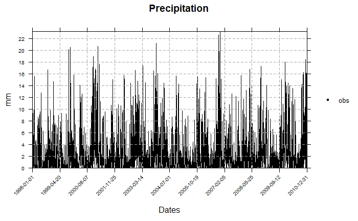

```r
obs <- subsetGrid(obs, years = 1998:2010)
temporalPlot(obs, xyplot.custom = list(main = "Precipitation", ylab = "mm"))
```

Loading the .ncml file corresponding to TRMM daily data.

```r
setwd("C:/Users/usuario/Desktop/TRMM_3B42_Daily_V7")
```

```
The working directory was changed to C:/Users/usuario/Desktop/TRMM_3B42_Daily_V7 inside a notebook chunk. The working directory will be reset when the chunk is finished running. Use the knitr root.dir option in the setup chunk to change the working directory for notebook chunks.
```

```r
inventory <- dataInventory("inventory.ncml")
```

```
[2020-12-22 11:31:58] Doing inventory ...
[2020-12-22 11:32:02] Retrieving info for 'precipitation_cnt' (7 vars remaining)
[2020-12-22 11:32:02] Retrieving info for 'IRprecipitation' (6 vars remaining)
[2020-12-22 11:32:02] Retrieving info for 'IRprecipitation_cnt' (5 vars remaining)
[2020-12-22 11:32:02] Retrieving info for 'HQprecipitation' (4 vars remaining)
[2020-12-22 11:32:03] Retrieving info for 'HQprecipitation_cnt' (3 vars remaining)
[2020-12-22 11:32:03] Retrieving info for 'randomError' (2 vars remaining)
[2020-12-22 11:32:03] Retrieving info for 'randomError_cnt' (1 vars remaining)
[2020-12-22 11:32:03] Retrieving info for 'precipitation' (0 vars remaining)
[2020-12-22 11:32:03] Done.
```

```r
str(inventory)
```

[output not shown]

[output cut: 111 more lines]

[output not shown]

TRMM year,longitude and latitude subsetting.

```r
trmm <- loadGridData(dataset = "C:/Users/usuario/Desktop/TRMM_3B42_Daily_V7/inventory.ncml",
             var = "precipitation",
             lonLim = c(-10,4.5),
             latLim = c(34.7,44) ,
             years = 1998:2010)
```

```
[2020-12-22 11:33:03] Defining geo-location parameters
[2020-12-22 11:33:03] Defining time selection parameters
[2020-12-22 11:33:03] Retrieving data subset ...
[2020-12-22 11:33:54] Done
```

Complete time series of the total data selected.

```
pad applied on the interval: day
```

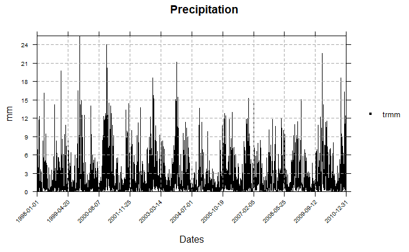

```r
temporalPlot(trmm, xyplot.custom = list(main = "Precipitation", ylab = "mm"))
```

Comparision of both time series

```
pad applied on the interval: day
pad applied on the interval: day
```

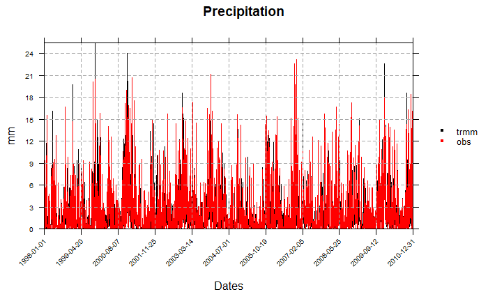

```r
temporalPlot(trmm,obs, xyplot.custom = list(main = "Precipitation", ylab = "mm"))
```

A bias correction of each method mentioned above is going to be made:

- Scaling
- Eqm
- Pqm
- Gpqm

Then, the comparision between the three time series (observation, trmm and calibration) is shown. For this calibration, we use leave one year out as crossvalidation method.

```r
cal <- biasCorrection(y = obs, x = trmm, newdata = trmm, precipitation = TRUE, method = "scaling",cross.val = "loo", scaling.type = "multiplicative")
```

[output not shown]

[output cut: 14 more lines]

[output not shown]

We plot obs agains cal time series as comparison. Finally, those time series and trmm time series are represented in the same plot. This step is repeated for each method.

```
pad applied on the interval: day
pad applied on the interval: day
```

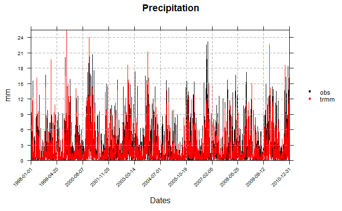

```r
temporalPlot(obs,trmm,xyplot.custom = list(main = "Precipitation", ylab = "mm"))
```

```
pad applied on the interval: day
pad applied on the interval: day
```

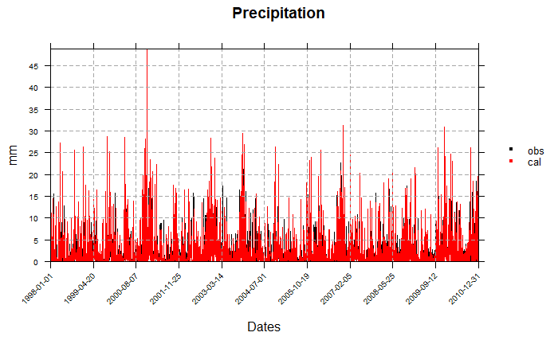

```r
temporalPlot(obs,cal,xyplot.custom = list(main = "Precipitation", ylab = "mm"))
```

```
pad applied on the interval: day
pad applied on the interval: day
pad applied on the interval: day
```

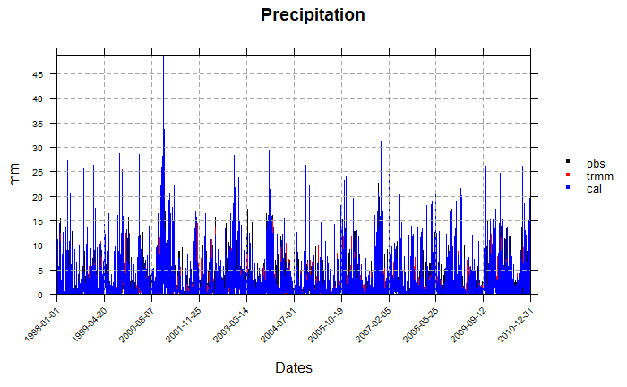

```r
temporalPlot(obs,trmm,cal,xyplot.custom = list(main = "Precipitation", ylab = "mm"))
```

```r
cal <- biasCorrection(y = obs, x = trmm, newdata = trmm, precipitation = TRUE,
                      cross.val = "loo", method = "eqm")
```

[output not shown]

[output cut: 14 more lines]

[output not shown]

```
pad applied on the interval: day
pad applied on the interval: day
```

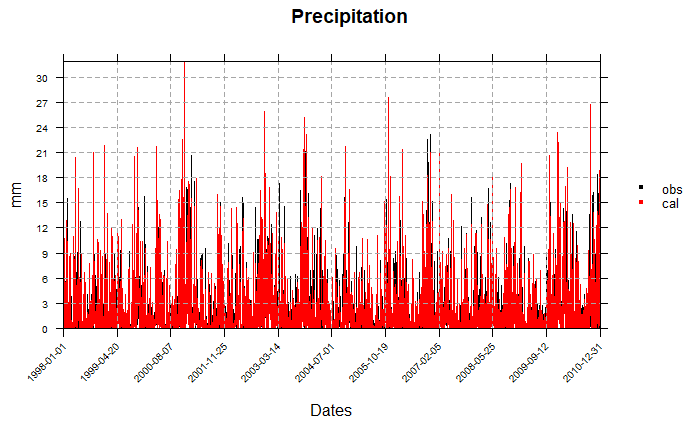

```r
temporalPlot(obs,cal,xyplot.custom = list(main = "Precipitation", ylab = "mm"))
```

```
pad applied on the interval: day
pad applied on the interval: day
pad applied on the interval: day
```

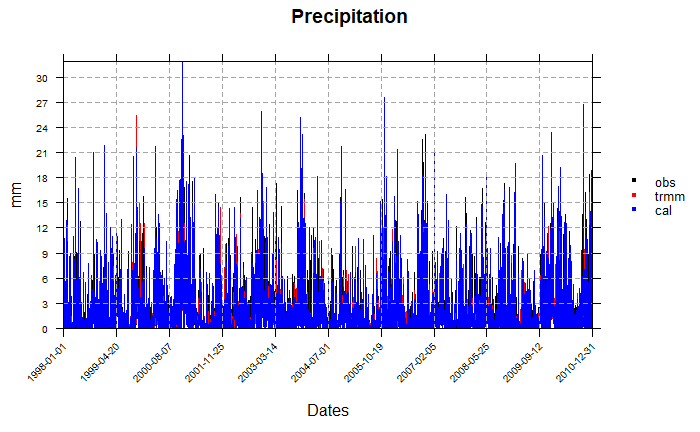

```r
temporalPlot(obs,trmm,cal,xyplot.custom = list(main = "Precipitation", ylab = "mm"))
```

```r
cal <- biasCorrection(y = obs, x = trmm, newdata = trmm, precipitation = TRUE,
                      cross.val = "loo",
                      method = "pqm",  fitdistr.args = list(densfun = "gamma"))
```

[output not shown]

[output cut: 14 more lines]

[output not shown]

```
pad applied on the interval: day
pad applied on the interval: day
```

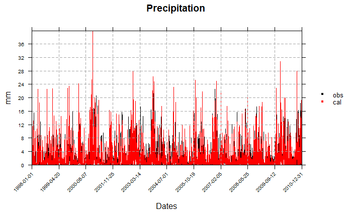

```r
temporalPlot(obs,cal,xyplot.custom = list(main = "Precipitation", ylab = "mm"))
```

```
pad applied on the interval: day
pad applied on the interval: day
pad applied on the interval: day
```

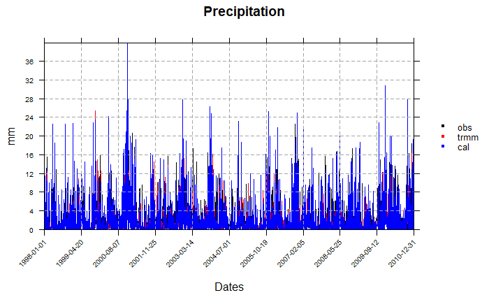

```r
temporalPlot(obs,trmm,cal,xyplot.custom = list(main = "Precipitation", ylab = "mm"))
```

```r
cal <- biasCorrection(y = obs, x = trmm, newdata = trmm, precipitation = TRUE,
                      cross.val = "loo",
                      method = "gpqm", theta = .70)
```

[output not shown]

[output cut: 14 more lines]

[output not shown]

```
pad applied on the interval: day
pad applied on the interval: day
```

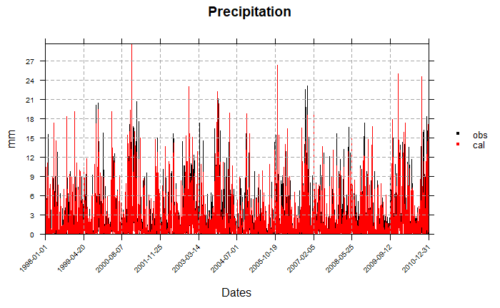

```r
temporalPlot(obs,cal,xyplot.custom = list(main = "Precipitation", ylab = "mm"))
```

```
pad applied on the interval: day
pad applied on the interval: day
pad applied on the interval: day
```

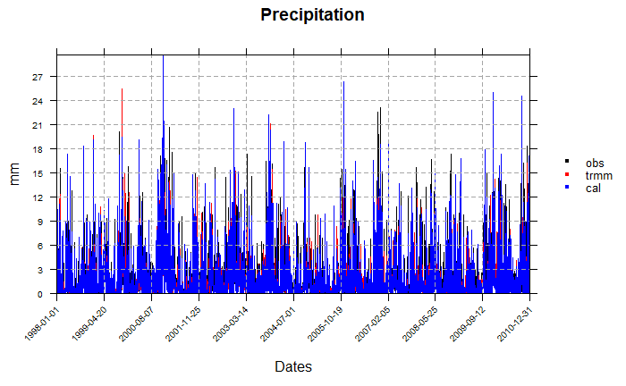

```r
temporalPlot(obs,trmm,cal,xyplot.custom = list(main = "Precipitation", ylab = "mm"))
```

This methodology is now carried out at a lower level in some of the observation stations.Obs-TRMM and Obs-Cal RMSE (Root Mean Squared Error) is computed in each station.

# MADRID-BARAJAS

```r
obs.station <- subsetGrid(obs, station.id = obs$Metadata$station_id[11])
idx <- which.min(abs(trmm$xyCoords$x - obs.station$xyCoords$x))
lon <- trmm$xyCoords$x[idx]

idx2 <- which.min(abs(trmm$xyCoords$y - obs.station$xyCoords$y))
lat <- trmm$xyCoords$y[idx2]

trmm.station <- subsetGrid(trmm, lonLim = lon, latLim = lat)

cal.station <- biasCorrection(y = obs.station, x = trmm.station, newdata = trmm.station, precipitation = TRUE, method = "scaling", cross.val = "loo", scaling.type = "multiplicative")
```

[output not shown]

[output cut: 14 more lines]

[output not shown]

```
pad applied on the interval: day
pad applied on the interval: day
```

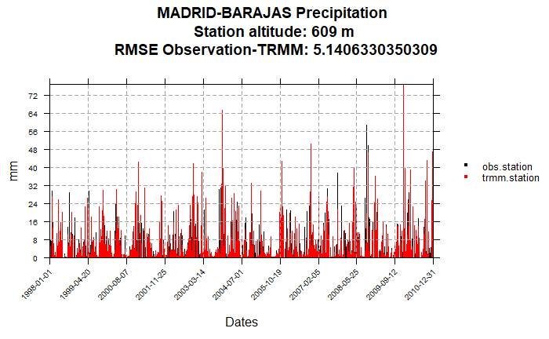

```r
temporalPlot(obs.station,trmm.station,
             xyplot.custom = list(main =paste(obs.station$Metadata$name,"Precipitation",                                         "\n",paste("Station altitude:", obs.station$Metadata$altitude, "m"), "\n",  "RMSE Observation-TRMM:", rmse(obs.station$Data, trmm.station$Data)),ylab = "mm"))
```

```
pad applied on the interval: day
pad applied on the interval: day
```

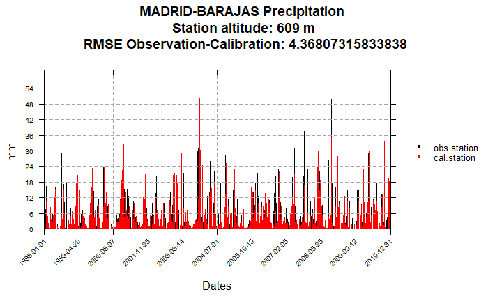

```r
temporalPlot(obs.station,cal.station,
             xyplot.custom = list(main =paste(obs.station$Metadata$name,"Precipitation",                                         "\n",paste("Station altitude:", obs.station$Metadata$altitude, "m"), "\n",  "RMSE Observation-Calibration:", rmse(obs.station$Data, cal.station$Data)),ylab = "mm"))
```

```
pad applied on the interval: day
pad applied on the interval: day
pad applied on the interval: day
```

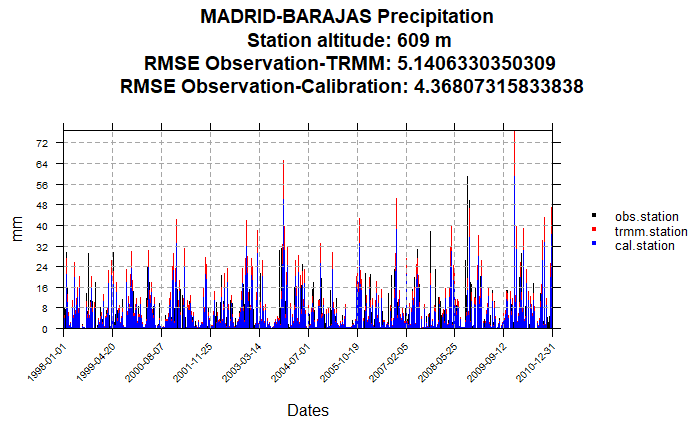

```r
temporalPlot(obs.station,trmm.station,cal.station,
             xyplot.custom = list(main =paste(obs.station$Metadata$name,"Precipitation",                                         "\n",paste("Station altitude:", obs.station$Metadata$altitude, "m"), "\n", "RMSE Observation-TRMM:", rmse(obs.station$Data, trmm.station$Data), "\n", "RMSE Observation-Calibration:", rmse(obs.station$Data, cal.station$Data)),ylab = "mm"))
```

```r
cal.station <- biasCorrection(y = obs.station, x = trmm.station, newdata = trmm.station, precipitation = TRUE, method = "eqm",cross.val = "loo")
```

[output not shown]

[output cut: 14 more lines]

[output not shown]

```
pad applied on the interval: day
pad applied on the interval: day
```

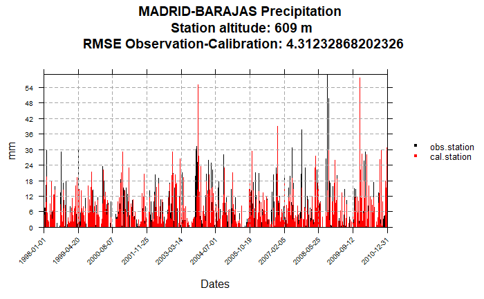

```r
temporalPlot(obs.station,cal.station,
             xyplot.custom = list(main =paste(obs.station$Metadata$name,"Precipitation",                                         "\n",paste("Station altitude:", obs.station$Metadata$altitude, "m"), "\n",  "RMSE Observation-Calibration:", rmse(obs.station$Data, cal.station$Data)),ylab = "mm"))
```

```
pad applied on the interval: day
pad applied on the interval: day
pad applied on the interval: day
```

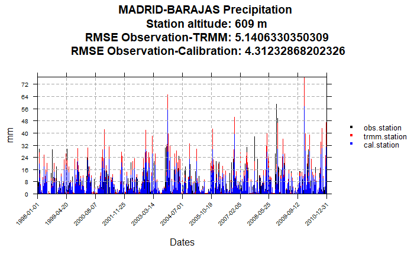

```r
temporalPlot(obs.station,trmm.station,cal.station,
             xyplot.custom = list(main =paste(obs.station$Metadata$name,"Precipitation",                                         "\n",paste("Station altitude:", obs.station$Metadata$altitude, "m"), "\n", "RMSE Observation-TRMM:", rmse(obs.station$Data, trmm.station$Data), "\n", "RMSE Observation-Calibration:", rmse(obs.station$Data, cal.station$Data)),ylab = "mm"))
```

```r
cal.station <- biasCorrection(y = obs.station, x = trmm.station, newdata = trmm.station, precipitation = TRUE, method = "pqm", cross.val = "loo",fitdistr.args = list(densfun = "gamma"))
```

[output not shown]

[output cut: 14 more lines]

[output not shown]

```
pad applied on the interval: day
pad applied on the interval: day
```

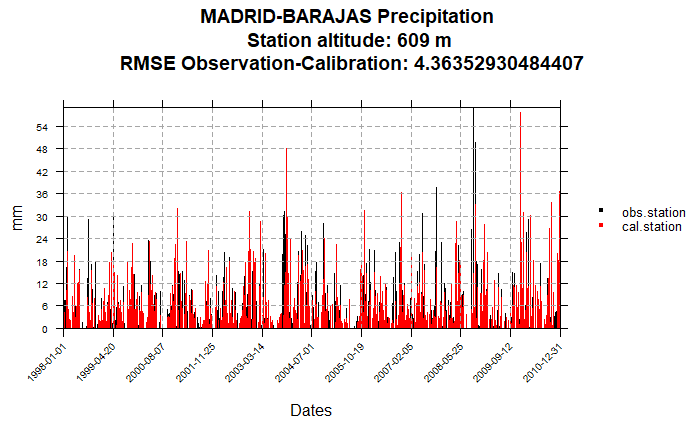

```r
temporalPlot(obs.station,cal.station,
             xyplot.custom = list(main =paste(obs.station$Metadata$name,"Precipitation",                                         "\n",paste("Station altitude:", obs.station$Metadata$altitude, "m"), "\n",  "RMSE Observation-Calibration:", rmse(obs.station$Data, cal.station$Data)),ylab = "mm"))
```

```
pad applied on the interval: day
pad applied on the interval: day
pad applied on the interval: day
```

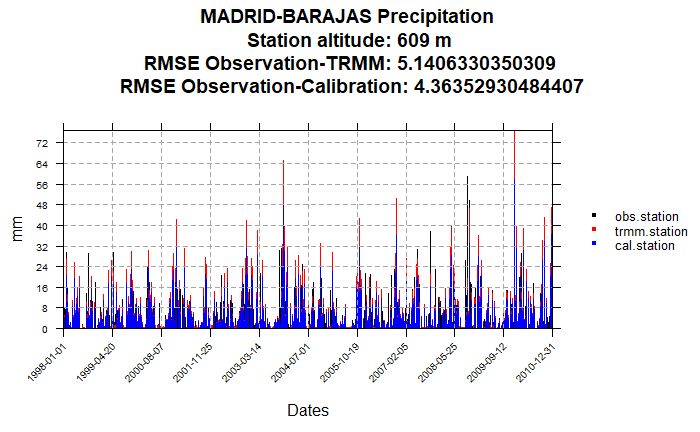

```r
temporalPlot(obs.station,trmm.station,cal.station,
             xyplot.custom = list(main =paste(obs.station$Metadata$name,"Precipitation",                                         "\n",paste("Station altitude:", obs.station$Metadata$altitude, "m"), "\n", "RMSE Observation-TRMM:", rmse(obs.station$Data, trmm.station$Data), "\n", "RMSE Observation-Calibration:", rmse(obs.station$Data, cal.station$Data)),ylab = "mm"))
```

```r
cal.station <- biasCorrection(y = obs.station, x = trmm.station, newdata = trmm.station, precipitation = TRUE, method = "gpqm",cross.val = "loo", theta = 0.70)
```

[output not shown]

[output cut: 14 more lines]

[output not shown]

```
pad applied on the interval: day
pad applied on the interval: day
```

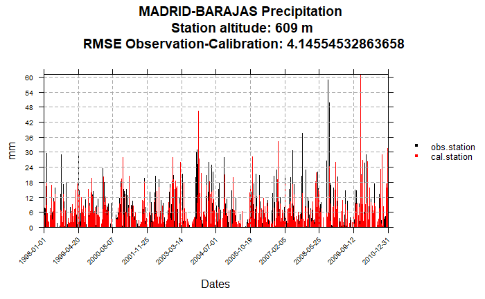

```r
temporalPlot(obs.station,cal.station,
             xyplot.custom = list(main =paste(obs.station$Metadata$name,"Precipitation",                                         "\n",paste("Station altitude:", obs.station$Metadata$altitude, "m"), "\n",  "RMSE Observation-Calibration:", rmse(obs.station$Data, cal.station$Data)),ylab = "mm"))
```

```
pad applied on the interval: day
pad applied on the interval: day
pad applied on the interval: day
```

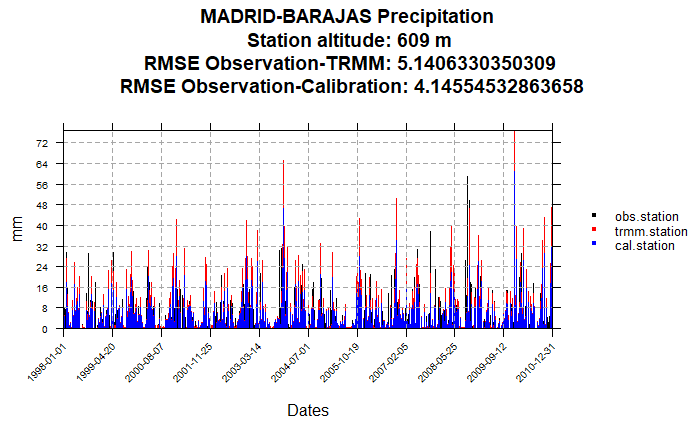

```r
temporalPlot(obs.station,trmm.station,cal.station,
             xyplot.custom = list(main =paste(obs.station$Metadata$name,"Precipitation",                                         "\n",paste("Station altitude:", obs.station$Metadata$altitude, "m"), "\n", "RMSE Observation-TRMM:", rmse(obs.station$Data, trmm.station$Data), "\n", "RMSE Observation-Calibration:", rmse(obs.station$Data, cal.station$Data)),ylab = "mm"))
```

# MÁLAGA

```r
obs.station <- subsetGrid(obs, station.id = obs$Metadata$station_id[4])
idx <- which.min(abs(trmm$xyCoords$x - obs.station$xyCoords$x))
lon <- trmm$xyCoords$x[idx]

idx2 <- which.min(abs(trmm$xyCoords$y - obs.station$xyCoords$y))
lat <- trmm$xyCoords$y[idx2]

trmm.station <- subsetGrid(trmm, lonLim = lon, latLim = lat)

cal.station <- biasCorrection(y = obs.station, x = trmm.station, newdata = trmm.station, precipitation = TRUE, method = "scaling",cross.val = "loo", scaling.type = "multiplicative")
```

[output not shown]

[output cut: 14 more lines]

[output not shown]

```
pad applied on the interval: day
pad applied on the interval: day
```

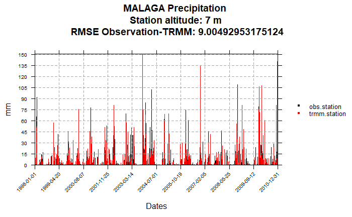

```r
temporalPlot(obs.station,trmm.station,
             xyplot.custom = list(main =paste(obs.station$Metadata$name,"Precipitation",                                         "\n",paste("Station altitude:", obs.station$Metadata$altitude, "m"), "\n",  "RMSE Observation-TRMM:", rmse(obs.station$Data, trmm.station$Data)),ylab = "mm"))
```

```
pad applied on the interval: day
pad applied on the interval: day
```

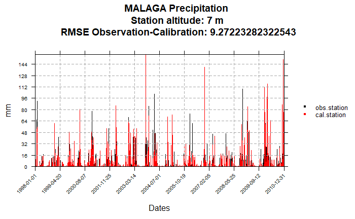

```r
temporalPlot(obs.station,cal.station,
             xyplot.custom = list(main =paste(obs.station$Metadata$name,"Precipitation",                                         "\n",paste("Station altitude:", obs.station$Metadata$altitude, "m"), "\n",  "RMSE Observation-Calibration:", rmse(obs.station$Data, cal.station$Data)),ylab = "mm"))
```

```
pad applied on the interval: day
pad applied on the interval: day
pad applied on the interval: day
```

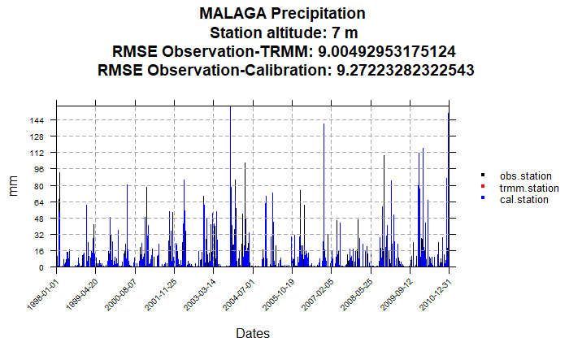

```r
temporalPlot(obs.station,trmm.station,cal.station,
             xyplot.custom = list(main =paste(obs.station$Metadata$name,"Precipitation",                                         "\n",paste("Station altitude:", obs.station$Metadata$altitude, "m"), "\n", "RMSE Observation-TRMM:", rmse(obs.station$Data, trmm.station$Data), "\n", "RMSE Observation-Calibration:", rmse(obs.station$Data, cal.station$Data)),ylab = "mm"))
```

```r
cal.station <- biasCorrection(y = obs.station, x = trmm.station, newdata = trmm.station, precipitation = TRUE, method = "eqm",cross.val = "loo")
```

[output not shown]

[output cut: 14 more lines]

[output not shown]

```
pad applied on the interval: day
pad applied on the interval: day
```

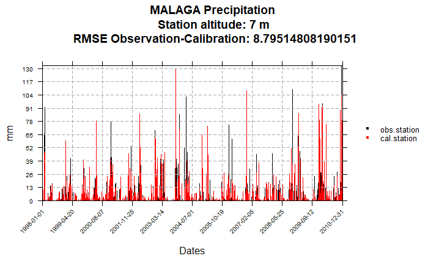

```r
temporalPlot(obs.station,cal.station,
             xyplot.custom = list(main =paste(obs.station$Metadata$name,"Precipitation",                                         "\n",paste("Station altitude:", obs.station$Metadata$altitude, "m"), "\n",  "RMSE Observation-Calibration:", rmse(obs.station$Data, cal.station$Data)),ylab = "mm"))
```

```
pad applied on the interval: day
pad applied on the interval: day
pad applied on the interval: day
```

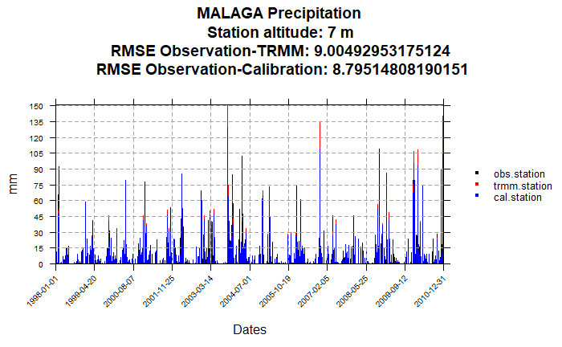

```r
temporalPlot(obs.station,trmm.station,cal.station,
             xyplot.custom = list(main =paste(obs.station$Metadata$name,"Precipitation",                                         "\n",paste("Station altitude:", obs.station$Metadata$altitude, "m"), "\n", "RMSE Observation-TRMM:", rmse(obs.station$Data, trmm.station$Data), "\n", "RMSE Observation-Calibration:", rmse(obs.station$Data, cal.station$Data)),ylab = "mm"))
```

```r
cal.station <- biasCorrection(y = obs.station, x = trmm.station, newdata = trmm.station, precipitation = TRUE, method = "pqm", cross.val = "loo",fitdistr.args = list(densfun = "gamma"))
```

[output not shown]

[output cut: 14 more lines]

[output not shown]

```
pad applied on the interval: day
pad applied on the interval: day
```

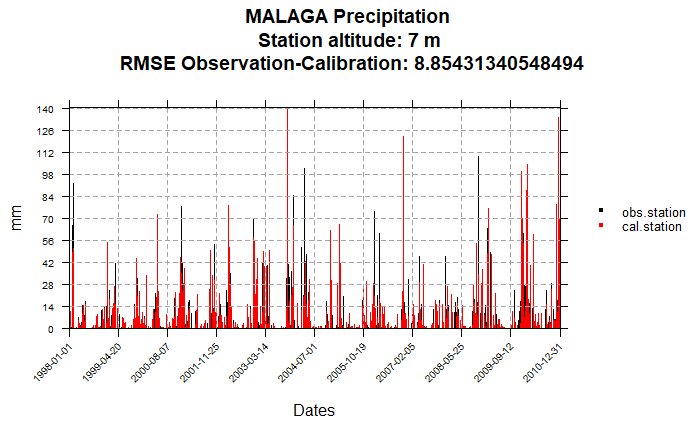

```r
temporalPlot(obs.station,cal.station,
             xyplot.custom = list(main =paste(obs.station$Metadata$name,"Precipitation",                                         "\n",paste("Station altitude:", obs.station$Metadata$altitude, "m"), "\n",  "RMSE Observation-Calibration:", rmse(obs.station$Data, cal.station$Data)),ylab = "mm"))
```

```
pad applied on the interval: day
pad applied on the interval: day
pad applied on the interval: day
```

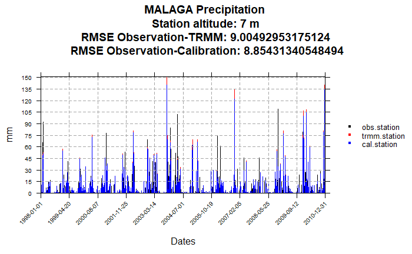

```r
temporalPlot(obs.station,trmm.station,cal.station,
             xyplot.custom = list(main =paste(obs.station$Metadata$name,"Precipitation",                                         "\n",paste("Station altitude:", obs.station$Metadata$altitude, "m"), "\n", "RMSE Observation-TRMM:", rmse(obs.station$Data, trmm.station$Data), "\n", "RMSE Observation-Calibration:", rmse(obs.station$Data, cal.station$Data)),ylab = "mm"))
```

```r
cal.station <- biasCorrection(y = obs.station, x = trmm.station, newdata = trmm.station, precipitation = TRUE, method = "gpqm",cross.val = "loo", theta = 0.70)
```

[output not shown]

[output cut: 14 more lines]

[output not shown]

```
pad applied on the interval: day
pad applied on the interval: day
```

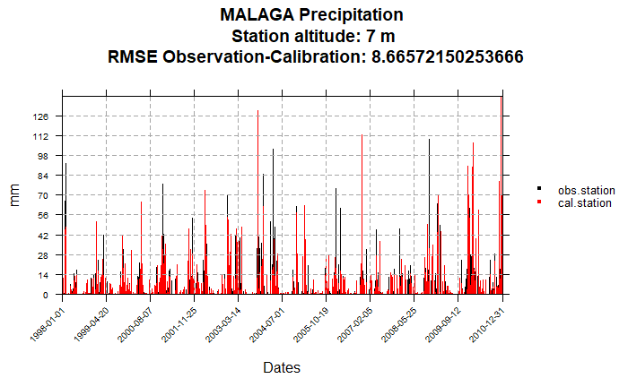

```r
temporalPlot(obs.station,cal.station,
             xyplot.custom = list(main =paste(obs.station$Metadata$name,"Precipitation",                                         "\n",paste("Station altitude:", obs.station$Metadata$altitude, "m"), "\n",  "RMSE Observation-Calibration:", rmse(obs.station$Data, cal.station$Data)),ylab = "mm"))
```

```
pad applied on the interval: day
pad applied on the interval: day
pad applied on the interval: day
```

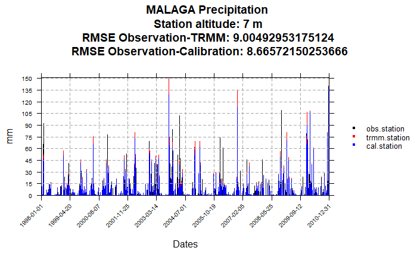

```r
temporalPlot(obs.station,trmm.station,cal.station,
             xyplot.custom = list(main =paste(obs.station$Metadata$name,"Precipitation",                                         "\n",paste("Station altitude:", obs.station$Metadata$altitude, "m"), "\n", "RMSE Observation-TRMM:", rmse(obs.station$Data, trmm.station$Data), "\n", "RMSE Observation-Calibration:", rmse(obs.station$Data, cal.station$Data)),ylab = "mm"))
```

#PALMA DE MALLORCA

```r
obs.station <- subsetGrid(obs, station.id = obs$Metadata$station_id[10])
idx <- which.min(abs(trmm$xyCoords$x - obs.station$xyCoords$x))
lon <- trmm$xyCoords$x[idx]

idx2 <- which.min(abs(trmm$xyCoords$y - obs.station$xyCoords$y))
lat <- trmm$xyCoords$y[idx2]

trmm.station <- subsetGrid(trmm, lonLim = lon, latLim = lat)

cal.station <- biasCorrection(y = obs.station, x = trmm.station, newdata = trmm.station, precipitation = TRUE, method = "scaling", cross.val = "loo",scaling.type = "multiplicative")
```

[output not shown]

[output cut: 14 more lines]

[output not shown]